# Assignment MVA Cluster Analysis

2024-03-09

```r
# Load required libraries
library(cluster)     # For cluster analysis
library(readr)       # For reading data files
library(factoextra)  # For visualizing multivariate analysis results
library(magrittr)    # For using the pipe operator %>%
library(NbClust)     # For determining the optimal number of clusters
```

```r
#for loading csv data
library(readr)

# Read the CSV file
df <- read_csv("C:/Rutgers/Subjects/Spring Sem/Multivariate Analysis/Data/wine_new.csv")
#dataframe
df
```

```
## # A tibble: 1,143 × 12
##    `fixed acidity` `volatile acidity` `citric acid` `residual sugar` chlorides
##              <dbl>              <dbl>         <dbl>            <dbl>     <dbl>
##  1             7.4               0.7           0                 1.9     0.076
##  2             7.8               0.88          0                 2.6     0.098
##  3             7.8               0.76          0.04              2.3     0.092
##  4            11.2               0.28          0.56              1.9     0.075
##  5             7.4               0.7           0                 1.9     0.076
##  6             7.4               0.66          0                 1.8     0.075
##  7             7.9               0.6           0.06              1.6     0.069
##  8             7.3               0.65          0                 1.2     0.065
##  9             7.8               0.58          0.02              2       0.073
## 10             6.7               0.58          0.08              1.8     0.097
## # ℹ 1,133 more rows
## # ℹ 7 more variables: `free sulfur dioxide` <dbl>,
## #   `total sulfur dioxide` <dbl>, density <dbl>, pH <dbl>, sulphates <dbl>,
## #   alcohol <dbl>, quality <chr>
```

selected these columns because of positive and negative correlation, other columns were not beneficial for analysis

```r
# Assuming df is your dataframe
attach(df)

#selected these columns because of positive and negative correlation, other columns were not beneficial for analysis
selected_cols <- df[, c("volatile acidity", "citric acid", "chlorides", "sulphates", "alcohol","quality")]

selected_cols
```

```
## # A tibble: 1,143 × 6
##    `volatile acidity` `citric acid` chlorides sulphates alcohol quality
##                 <dbl>         <dbl>     <dbl>     <dbl>   <dbl> <chr>
##  1               0.7           0        0.076      0.56     9.4 Average
##  2               0.88          0        0.098      0.68     9.8 Average
##  3               0.76          0.04     0.092      0.65     9.8 Average
##  4               0.28          0.56     0.075      0.58     9.8 Good
##  5               0.7           0        0.076      0.56     9.4 Average
##  6               0.66          0        0.075      0.56     9.4 Average
##  7               0.6           0.06     0.069      0.46     9.4 Average
##  8               0.65          0        0.065      0.47    10   Very Good
##  9               0.58          0.02     0.073      0.57     9.5 Very Good
## 10               0.58          0.08     0.097      0.54     9.2 Average
## # ℹ 1,133 more rows
```

column 6 which is quality (Categorical: Target variable) Range parameters: Bad, Poor, Average, Good, Very Good, Excellent

Why I chose these attributes for cluster?

Answer:

volatile acidity: neagtively correlated to target variable

Citric acid: Positively correlated

similar correlation for columns selected showing no randomness

Group by quality and calculate the average of all other attributes within each group

Also assigning groups(random) Assigning groups to target variable:

Ideal range of quality is mention below (ascending)

group number is random

Bad: 2 Poor: 5 Average: 1 Good: 4 Very Good: 6 Excellent: 3

```r
# Group by column 6 and calculate the average of all other columns within each group
grouped_avg <- aggregate(. ~ quality, data = selected_cols[, -6], FUN = mean)

# Print the grouped averages
print(grouped_avg)
```

```
##     quality volatile acidity citric acid  chlorides sulphates   alcohol
## 1   Average        0.5852795   0.2401242 0.09177019 0.6133747  9.902277
## 2       Bad        0.8975000   0.2116667 0.10533333 0.5500000  9.691667
## 3 Excellent        0.4100000   0.4325000 0.07018750 0.7662500 11.937500
## 4      Good        0.5049567   0.2636797 0.08528139 0.6765368 10.655339
## 5      Poor        0.7000000   0.1657576 0.09478788 0.6378788 10.260606
## 6 Very Good        0.3936713   0.3865734 0.07521678 0.7435664 11.482634
```

setting target variable as row name by removing it first

grouping values based on alcohol and assigning a value to target variable based on that

Observation:

as alcohol content increase quality of alcohol also improves as highest scores are assigned to excellent quality of wine based on group number

Lowest values of alcohol are assigned to bad quality wine

```r
# Set the first column as row names
row.names(grouped_avg) <- grouped_avg[, 1]  # Assuming the first column contains row names

# Remove the first column from the dataframe
grouped_avg <- grouped_avg[, -1]

# View the dataframe
grouped_avg
```

```
##           volatile acidity citric acid  chlorides sulphates   alcohol
## Average          0.5852795   0.2401242 0.09177019 0.6133747  9.902277
## Bad              0.8975000   0.2116667 0.10533333 0.5500000  9.691667
## Excellent        0.4100000   0.4325000 0.07018750 0.7662500 11.937500
## Good             0.5049567   0.2636797 0.08528139 0.6765368 10.655339
## Poor             0.7000000   0.1657576 0.09478788 0.6378788 10.260606
## Very Good        0.3936713   0.3865734 0.07521678 0.7435664 11.482634
```

Observation:

as alcohol content increase quality of alcohol also improves as highest scores are assigned to excellent quality of wine based on group number

Lowest values of alcohol are assigned to bad quality wine

based on this we can observe correlation of attribute with respect to target variable as i mentioned above

positive value of attributes means correlated

Negative value of attributes means negatively correlated

```r
matstd.can <- scale(grouped_avg)
matstd.can
```

```
##           volatile acidity citric acid  chlorides  sulphates       alcohol
## Average         0.01758824  -0.4157915  0.3597692 -0.6288205 -0.8436926707
## Bad             1.64310930  -0.6893140  1.4037560 -1.4067659 -1.0797555321
## Excellent      -0.89497363   1.4332464 -1.3015000  1.2477728  1.4374844590
## Good           -0.40059824  -0.1893863 -0.1396888  0.1465142  0.0003757336
## Poor            0.61486032  -1.1305735  0.5920480 -0.3280254 -0.4420603952
## Very Good      -0.97998599   0.9918188 -0.9143845  0.9693247  0.9276484054
## attr(,"scaled:center")
## volatile acidity      citric acid        chlorides        sulphates
##       0.58190126       0.28338359       0.08709618       0.66460113
##          alcohol
##      10.65500388
## attr(,"scaled:scale")
## volatile acidity      citric acid        chlorides        sulphates
##       0.19207410       0.10404101       0.01299168       0.08146425
##          alcohol
##       0.89218086
```

Calculating Euclidean distance of target variable values:

Excellent has highest distance to Bad which is worst quality of wine

The distance is less for similar quality example:

[1] Excellent and very good

[2] Poor and Bad

```r
# Creating a (Euclidean) distance matrix of the standardized data
dist.wine <- dist(matstd.can, method="euclidean")
dist.wine
```

```
##             Average       Bad Excellent      Good      Poor
## Bad       2.1137565
## Excellent 3.9669759 5.6257098
## Good      1.3376072 3.2230813 2.7395622
## Poor      1.0832299 1.8658007 4.2958264 1.6951005
## Very Good 3.2080689 4.9755491 0.8303072 1.9667081 3.5884039
```

Invoking Hierarchial cluster with method single

```r
# Invoking hclust command (cluster analysis by single linkage method)
cluswine.nn <- hclust(dist.wine, method = "single")
```

Observation: Excellent and very good quality of wine have a single parent

Poor and Good are in same branch. (Average quality wine is also in same branch)

Bad quality wine which has score extremely low is standalone branch in heirarchial cluster

Number of Hierarchies: 3

we can form 2 groups:

[1] Excellent and very good quality

[2] Bad, Average, Poor and Good

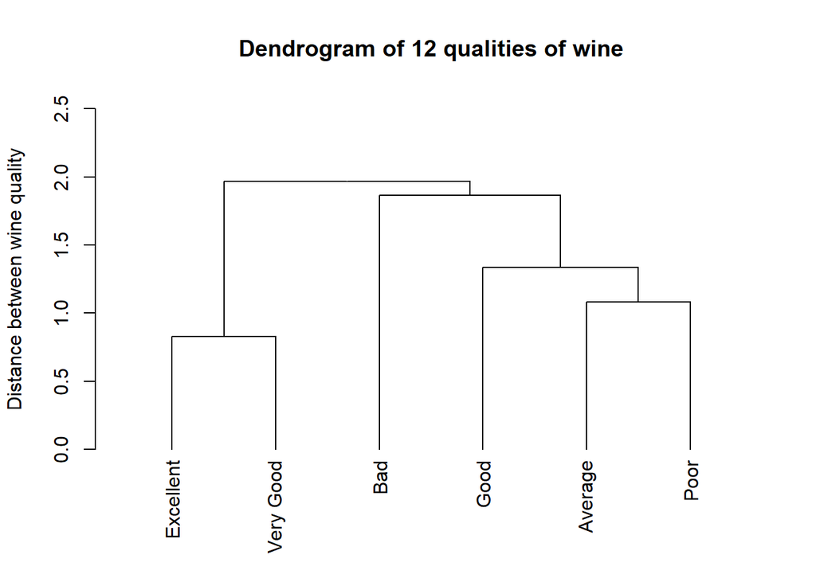

```r
# Plotting vertical dendrogram
# create extra margin room in the dendrogram, on the bottom (Canine species' labels)
#par(mar=c(6, 4, 4, 2) + 0.1)
plot(as.dendrogram(cluswine.nn),ylab="Distance between wine quality",ylim=c(0,2.5),main="Dendrogram of 12 qualities of wine")
```

Applying scaling again for new operation

Volatile Acidity: The “Bad” quality category tends to have significantly higher volatile acidity compared to other categories, while “Very Good” and “Excellent” categories have lower than average volatile acidity.

Citric Acid: The “Bad” and “Poor” quality categories exhibit lower citric acid levels compared to the other categories, with “Excellent” having the highest average citric acid content.

Alcohol: “Excellent” quality wines have the highest alcohol content, while “Bad” quality wines have the lowest.

Overall, these observations suggest that certain chemical properties like volatile acidity, citric acid, chlorides, sulphates, and alcohol content vary significantly across different quality categories of wines.

```r
matstd.can
```

```
##           volatile acidity citric acid  chlorides  sulphates       alcohol
## Average         0.01758824  -0.4157915  0.3597692 -0.6288205 -0.8436926707
## Bad             1.64310930  -0.6893140  1.4037560 -1.4067659 -1.0797555321
## Excellent      -0.89497363   1.4332464 -1.3015000  1.2477728  1.4374844590
## Good           -0.40059824  -0.1893863 -0.1396888  0.1465142  0.0003757336
## Poor            0.61486032  -1.1305735  0.5920480 -0.3280254 -0.4420603952
## Very Good      -0.97998599   0.9918188 -0.9143845  0.9693247  0.9276484054
## attr(,"scaled:center")
## volatile acidity      citric acid        chlorides        sulphates
##       0.58190126       0.28338359       0.08709618       0.66460113
##          alcohol
##      10.65500388
## attr(,"scaled:scale")
## volatile acidity      citric acid        chlorides        sulphates
##       0.19207410       0.10404101       0.01299168       0.08146425
##          alcohol
##       0.89218086
```

```r
matstd.wine_new <- scale(matstd.can[,1:5])
matstd.wine_new
```

```
##           volatile acidity citric acid  chlorides  sulphates       alcohol
## Average         0.01758824  -0.4157915  0.3597692 -0.6288205 -0.8436926707
## Bad             1.64310930  -0.6893140  1.4037560 -1.4067659 -1.0797555321
## Excellent      -0.89497363   1.4332464 -1.3015000  1.2477728  1.4374844590
## Good           -0.40059824  -0.1893863 -0.1396888  0.1465142  0.0003757336
## Poor            0.61486032  -1.1305735  0.5920480 -0.3280254 -0.4420603952
## Very Good      -0.97998599   0.9918188 -0.9143845  0.9693247  0.9276484054
## attr(,"scaled:center")
## volatile acidity      citric acid        chlorides        sulphates
##    -7.979728e-17     6.013708e-17     1.850372e-16     7.123931e-16
##          alcohol
##    -1.004839e-15
## attr(,"scaled:scale")
## volatile acidity      citric acid        chlorides        sulphates
##                1                1                1                1
##          alcohol
##                1
```

Observation: Excellent and very good quality of wine have a single parent

Poor and Good are in same branch. (Average quality wine is also in same branch)

Bad quality wine which has score extremely low is standalone branch in heirarchial cluster

Number of Hierarchies: 3

we can form 2 groups:

[1] Excellent and very good quality

[2] Bad, Average, Poor and Good

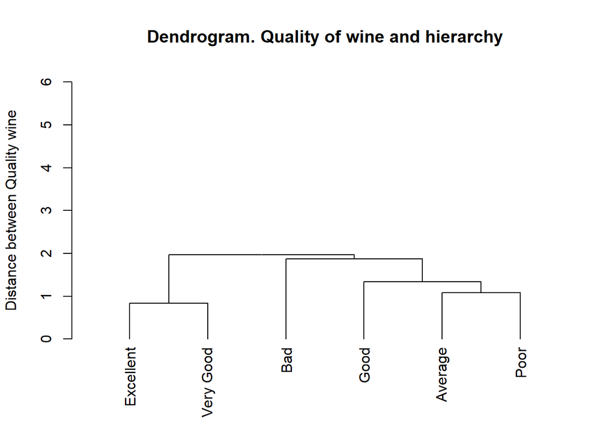

```r
# Creating a (Euclidean) distance matrix of the standardized data
dist.employ <- dist(matstd.wine_new, method="euclidean")
# Invoking hclust command (cluster analysis by single linkage method)
clusemploy.nn <- hclust(dist.employ, method = "single")

plot(as.dendrogram(clusemploy.nn),ylab="Distance between Quality wine",ylim=c(0,6),
     main="Dendrogram. Quality of wine and hierarchy")
```

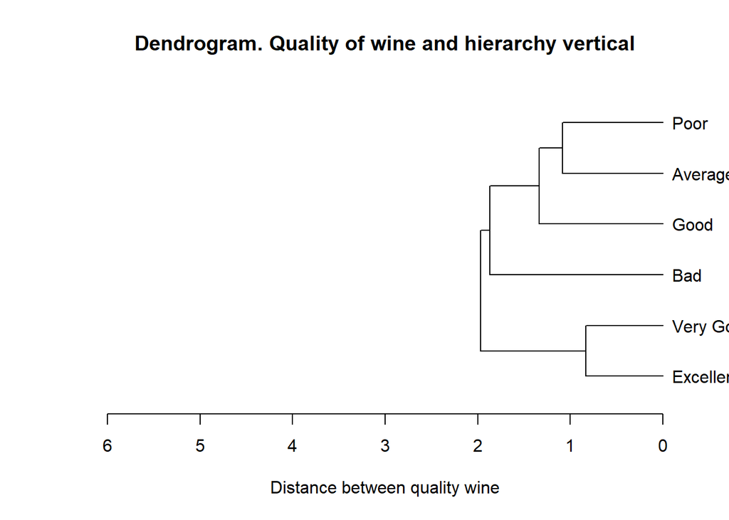

```r
plot(as.dendrogram(clusemploy.nn), xlab= "Distance between quality wine", xlim=c(6,0),
     horiz = TRUE,main="Dendrogram. Quality of wine and hierarchy vertical")
```

```r
# We will use agnes function as it allows us to select option for data standardization, the distance measure and clustering algorithm in one single function

agn.employ <- agnes(matstd.can, metric="euclidean", stand=TRUE, method = "single")
```

Merging operation and making 2 clusters:

The agn.employ$merge output appears to show the sequence of cluster merging in an agglomerative hierarchical clustering process. Each row represents a step in the merging process. The two numbers in each row indicate the indices of the clusters that were merged at that step.

This information is crucial for understanding the hierarchical structure of the clustering process and can be used to determine the hierarchy of clusters and the relationships between them.

```r
#  Description of cluster merging
agn.employ$merge
```

```
##      [,1] [,2]
## [1,]   -3   -6
## [2,]   -1   -5
## [3,]    2   -4
## [4,]    3   -2
## [5,]    4    1
```

Agglomerative clustering is more accurate with producing hierarchy

It mapped the wine quality more accurately:

Rest of the observations are same

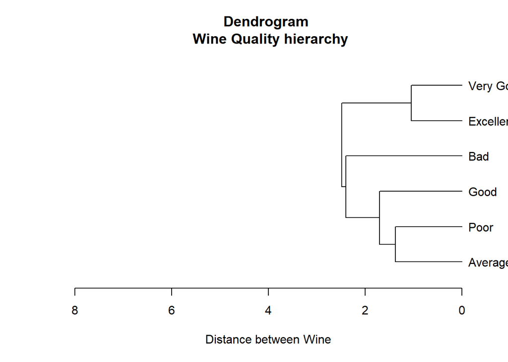

```r
#Dendogram
plot(as.dendrogram(agn.employ), xlab= "Distance between Wine",xlim=c(8,0),
     horiz = TRUE,main="Dendrogram \n Wine Quality hierarchy")
```

The agglomerative coefficient here tells us that the data tends to form clusters to some extent. With a coefficient of 0.4, it means that there’s a moderate tendency for the data points to group together. This suggests that there might be some identifiable patterns or similarities among the data points, but these clusters might not be as clear-cut or distinct as they would be if the coefficient were closer to 1.

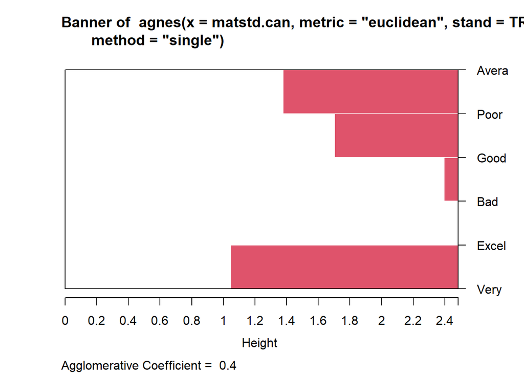

```r
#Interactive Plots
#plot(agn.employ,ask=TRUE)
plot(agn.employ, which.plots=1)
```

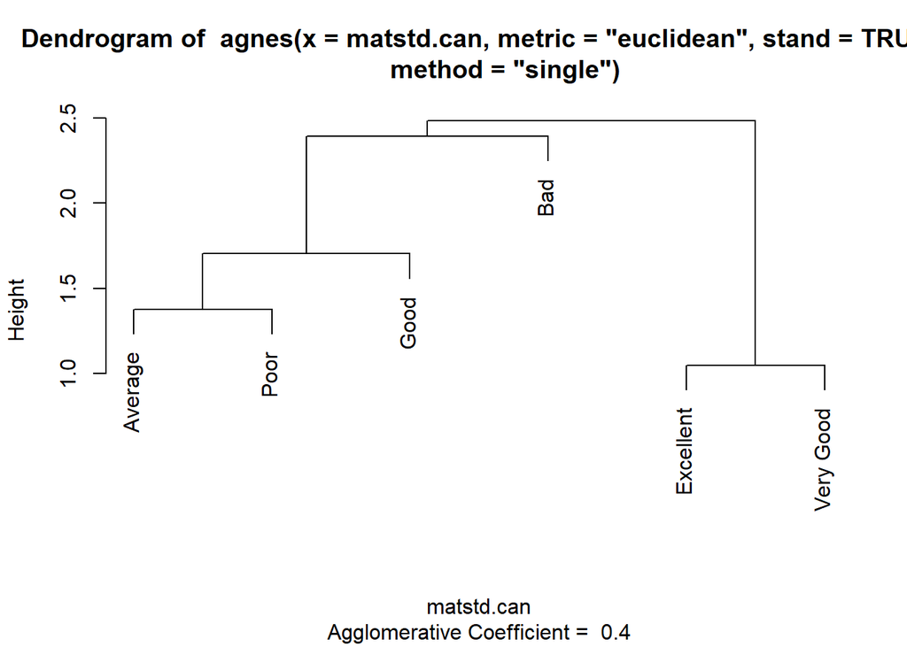

```r
plot(agn.employ, which.plots=2)
```

```r
plot(agn.employ, which.plots=3)
```

Looking at the standardized data, it seems we’re dealing with various attributes related to wine quality. Each row represents a different category or quality level, and the columns represent different features like volatile acidity, citric acid, chlorides, sulphates, and alcohol content.

By standardizing the data, we’ve made it easier to compare across different features. Now, when we apply K-means clustering, we’re essentially trying to find natural groupings within the data based on these standardized features. We’re exploring how wines might naturally cluster together based on their characteristics.

We’re trying different values of k, which determine the number of clusters we’re looking for. Each cluster represents a group of wines that share similar characteristics according to the features we’ve selected.